# Visualizing sort algorithms with ggplot2

ggplot2

data-visualization

Just learning ggplot2 with inspiration from looking at Sorting Algorithms by Mike Bostock

Joshua Kunst http://jkunst.com/  
09-25-2015

Have you read [Visualizing Algorithms](http://bost.ocks.org/mike/algorithms/) by Mike Bostock? It’s a *pure gold post*. In that post Mike show a *static* representation of a sort algorithm and obvious it will fun to replicate that image with ggplot2 so here we go.

We need some sorts algorithms. In [this](http://faculty.cs.niu.edu/~hutchins/csci230/sorting.htm) link you can see some algorithms.

We start with Insertion sort:

```
library(dplyr)
library(tidyr)
library(ggplot2)
library(viridis)

theme_set(theme_void())

insertion_sort_steps <- function(x  = sample(1:15)){

  msteps <- matrix(data = x, ncol = length(x))

  for (i in 2:length(x)) {

    j <- i

    while ((j > 1) && (x[j] < x[j - 1])) {

      temp <- x[j]
      x[j] <- x[j - 1]
      x[j - 1] <- temp
      j <- j - 1

      msteps <- rbind(msteps, as.vector(x))

    }
  }

  msteps

}
```

Now to test it and see what the function do:

```
set.seed(12345)

x <- sample(seq(4))

x
```

```
[1] 2 3 4 1
```

```
msteps <- insertion_sort_steps(x)

as.data.frame(msteps)
```

```
  V1 V2 V3 V4
1  2  3  4  1
2  2  3  1  4
3  2  1  3  4
4  1  2  3  4
```

Every *row* is a step in sort the algorithm (a partial sort). This matrix is a hard to plot so we need a nicer structure. We can transform the matrix to a *data_frame* with the information of every *position* of every *element* in each *step*.

```
sort_matix_to_df <- function(msteps){

  df <- as.data.frame(msteps, row.names = NULL)

  names(df) <- seq(ncol(msteps))

  df_steps <- df %>%
    tbl_df() %>%
    mutate(step = seq(nrow(.))) %>%
    gather(position, element, -step) %>%
    arrange(step)

  df_steps

}
```

And we apply this function to the previous *steps matrix*.

```
df_steps <- sort_matix_to_df(msteps)

head(df_steps, 10)
```

```
# A tibble: 10 x 3
    step position element
   <int> <chr>      <int>
 1     1 1              2
 2     1 2              3
 3     1 3              4
 4     1 4              1
 5     2 1              2
 6     2 2              3
 7     2 3              1
 8     2 4              4
 9     3 1              2
10     3 2              1
```

The next step will be plot the data frame.

```
plot_sort <- function(df_steps, size = 5, color.low = "#D1F0E1", color.high = "#524BB4"){

  ggplot(df_steps,
         aes(step, position, group = element, color = element, label = element)) +
    geom_path(size = size, alpha = 1, lineend = "round") +
    scale_colour_gradient(low = color.low, high = color.high) +
    coord_flip() +
    scale_x_reverse() +
    theme(legend.position = "none")

}
```

Now compare this:

```
as.data.frame(msteps)
```

```
  V1 V2 V3 V4
1  2  3  4  1
2  2  3  1  4
3  2  1  3  4
4  1  2  3  4
```

With:

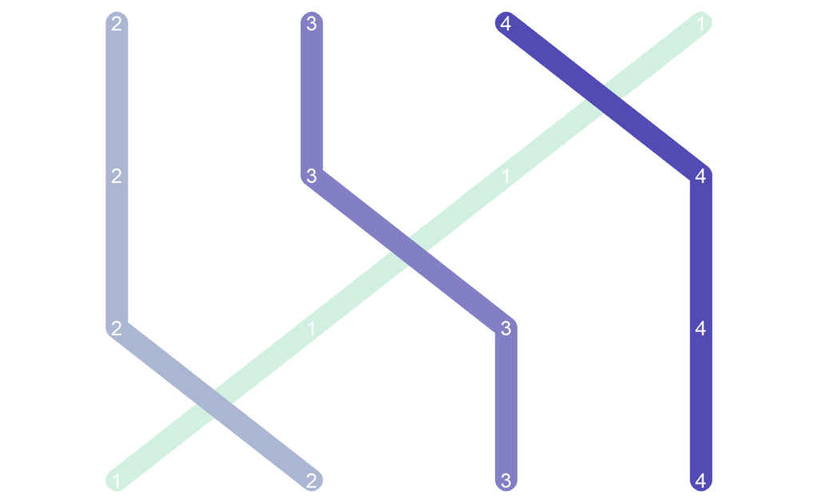

```
plot_sort(df_steps, size = 6) +
  geom_text(color = "white", size = 4)
```

It works, so we can now scroll!

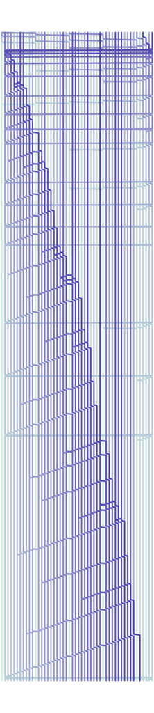

```
sample(seq(50)) %>%
  insertion_sort_steps() %>%
  sort_matix_to_df() %>%
  plot_sort(size = 2.0)
```

Now try with other sort algorithms:

Bubble sort:

```
bubble_sort_steps <- function(x = sample(1:15)){

  msteps <- matrix(data = x, ncol = length(x))

  for (i in 1:(length(x) - 1)) {

    for (j in 1:(length(x) - 1)) {

      if (x[j] > x[j + 1]) {
        temp <- x[j]
        x[j] <- x[j + 1]
        x[j + 1] <- temp
      }

      msteps <- rbind(msteps, as.vector(x))

    }
  }

  msteps

}
```

Selection sort:

```
selection_sort_steps <- function(x = sample(1:15)){

  msteps <- matrix(data = x, ncol = length(x))

  for (i in 1:(length(x) - 1)) {

    smallsub <- i

    for (j in (i + 1):(length(x) - 0)) { # Is not '- 1' like website

      if (x[j] < x[smallsub]) {
        smallsub <- j
      }
    }

    temp <- x[i]
    x[i] <- x[smallsub]
    x[smallsub] <- temp

    msteps <- rbind(msteps, as.vector(x))

  }

  msteps

}
```

Now test with a longer vector:

```
n <- 50
x <- sample(seq(n))

big_df <- rbind(
  x %>% selection_sort_steps() %>% sort_matix_to_df() %>% mutate(sort = "Selection Sort"),
  x %>% insertion_sort_steps() %>% sort_matix_to_df() %>% mutate(sort = "Insertion Sort"),
  x %>% bubble_sort_steps() %>% sort_matix_to_df() %>% mutate(sort = "Bubble Sort")
)

head(big_df)
```

```
# A tibble: 6 x 4
   step position element sort
  <int> <chr>      <int> <chr>
1     1 1             10 Selection Sort
2     1 2             43 Selection Sort
3     1 3             27 Selection Sort
4     1 4             34 Selection Sort
5     1 5             44 Selection Sort
6     1 6             35 Selection Sort
```

```
big_df %>%
  group_by(sort) %>%
  summarise(steps = n())
```

```
# A tibble: 3 x 2
  sort            steps
  <chr>           <int>
1 Bubble Sort    120100
2 Insertion Sort  32100
3 Selection Sort   2500
```

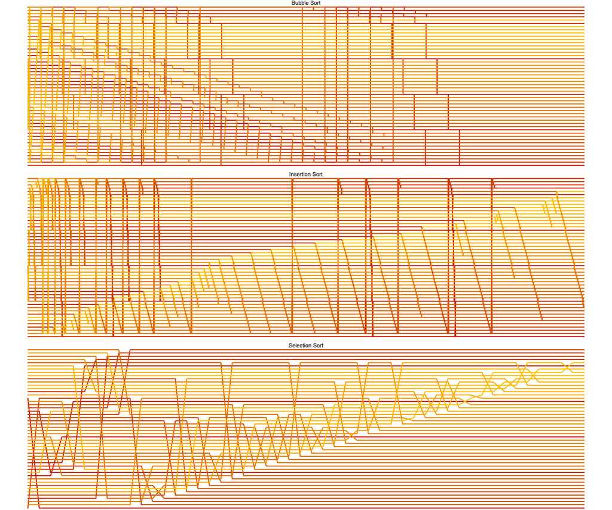

```
ggplot(
  big_df,
  aes(step, position, group = element, color = element, label = element)
  ) +
  geom_path(size = 0.8, alpha = 1, lineend = "round") +
  scale_colour_gradient(low = "#c21500", high = "#ffc500") + # http://uigradients.com/#Kyoto
  facet_wrap(~sort, scales = "free_x", ncol = 1) +
  theme(
    legend.position = "none",
    strip.background = element_rect(fill = "transparent", linetype = 0),
    strip.text = element_text(size = 8)
    )
```

Or we can plot vertically using the viridis palette from the [viridis package](https://github.com/sjmgarnier/viridis) :

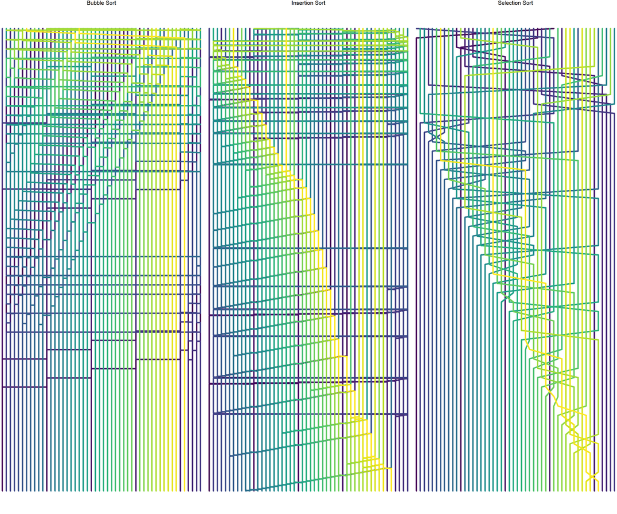

```
ggplot(
  big_df,
  aes(position, step, group = element, color = element, label = element)
  ) +
  geom_path(size = 1, alpha = 1, lineend = "round") +
  scale_colour_gradientn(colours = viridis_pal()(n)) +
  facet_wrap(~sort, scales = "free_y", nrow = 1) +
  scale_y_reverse() +
  theme(
    legend.position = "none",
    strip.background = element_rect(fill = "transparent", linetype = 0),
    strip.text = element_text(size = 8)
    )
```

And that’s it. If you write/implement another sort algorithm in this way let me know to view it ;).

References:

1. http://bost.ocks.org/mike/algorithms/
2. http://faculty.cs.niu.edu/~hutchins/csci230/sorting.htm
3. http://corte.si/posts/code/visualisingsorting/
4. http://uigradients.com/#Kyoto
5. http://algs4.cs.princeton.edu/21elementary/